# Intro to R Notebook

## Exercise 6

*When extracting from a 2-dimensional object, which number specifies rows and which specifies columns?*

```r
m<-matrix(data=1:25,ncol=5,byrow=T)
m
m[5,5]
```

```
 [,1] [,2] [,3] [,4] [,5]
```

[1,] 1 2 3 4 5 [2,] 6 7 8 9 10 [3,] 11 12 13 14 15 [4,] 16 17 18 19 20 [5,] 21 22 23 24 25 [1] 25

ncol is the column nrow is for the rows [row, column]

*What does `m[3,]` do?*

```r
m[3,]
```

[1] 11 12 13 14 15 It goes to the 3rd row of your matrix and displays it.

*How can you extract the 3rd, 4th and 5th columns of m together as one object?*

```r
m[,3:5]
```

```
[,1] [,2] [,3]
```

[1,] 3 4 5 [2,] 8 9 10 [3,] 13 14 15 [4,] 18 19 20 [5,] 23 24 25

## Exercise 7

*What does the cbind command do? How about rbind?*

```r
cbind(m,101:105)
```

```
 [,1] [,2] [,3] [,4] [,5] [,6]
```

[1,] 1 2 3 4 5 101 [2,] 6 7 8 9 10 102 [3,] 11 12 13 14 15 103 [4,] 16 17 18 19 20 104 [5,] 21 22 23 24 25 105

cbind combines the vectors and matrices by their columns (or adds a column of numbers you specify). rbind combines them by rows.

*Create a new object “n” where the first row is a new row of numbers (your choice) and the following rows are the followed by the m matrix.*

```r
n<-c(4,6,7,12,98)
o<-rbind(n,m)
o
o[2,]
```

[,1] [,2] [,3] [,4] [,5] n 4 6 7 12 98 1 2 3 4 5 6 7 8 9 10 11 12 13 14 15 16 17 18 19 20 21 22 23 24 25 [1] 1 2 3 4 5

Note: The matrix did not have names, so when the row “n” was inserted, the index for rows disappeared. It still recognizes the row order.

*Want more? (OPTIONAL) do the same but reverse the order of the rows from m.*

### Ciera’s Tutorial

Activity Break There are many ways to subset data and you can get a brief look with clear examples here.

1. Subset the data to only nerds and metalheads.

```r
nerdsandmetalheads<-subset(stereotypes, population=="nerd" | population=="metalheads")
```

2. Use what you have learned and this page as guidance for sub-setting a dataset to answer the question: Are there more males who binge drink (over 25 a week) and eat over 20 tacos a week in the metal heads or hipster population?

```r
hipsters<-subset(stereotypes, population=="hipster")
hipstermales<-subset(hipsters, gender=="male")
hipsterbingedrink<-subset(hipstermales, beer > 25)
hipsterbingeeats<-subset(hipsterbingedrink, tacos >20)
```

```r
metalheads<-subset(stereotypes, population=="metalhead")
mhmales<-subset(metalheads, gender=="male")
mhbingedrink<-subset(mhmales, beer > 25)
mhbingeeats<-subset(mhbingedrink, tacos >20)
```

3. Ask one more question about the dataset that you are interested in. Subset the data accordingly.

*Do females or males shower more often on average?*

```r
fem<-subset(stereotypes, gender == "female")
mal<-subset(stereotypes, gender=="male")
femshower<-sort(fem$shower)
malshower<-sort(mal$shower)
mean(fem$shower)
mean(mal$shower)
```

[output not shown]

4. In your own words explain what “==” means?

Find the word or value in the file.

# Visualization

**Visualization with ggplot2**_

View the distribution of showers. Color by population.

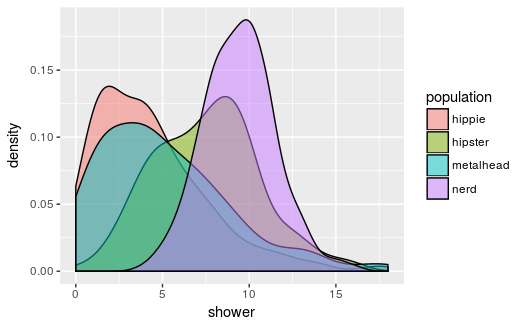

```r
qplot(shower, data=stereotypes, geom="density",alpha = I(0.5), fill=population)
```

View the distribution of beer consumption and color by gender.

```r
qplot(beer, data=stereotypes, geom="density",alpha = I(0.5), fill=gender)
```

[output not shown]

Find a way to create a plot using the the geom violin with the stereotype data set.

```r
s<-ggplot(data=stereotypes, aes(x=population, y=shower)) + geom_violin()
```

[output not shown]

**Combining Subset with Visualization**

1.Make a graph that visually describes the difference between beer consumption between gender in the nerd category.

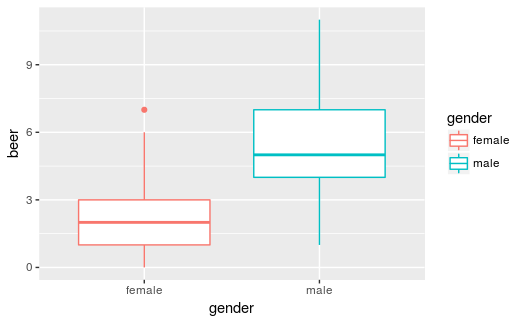

```r
nerds<- subset(stereotypes, population == "nerd")
ggplot(data=nerds, aes( x=gender, y=beer, colour=gender)) +geom_boxplot()
```

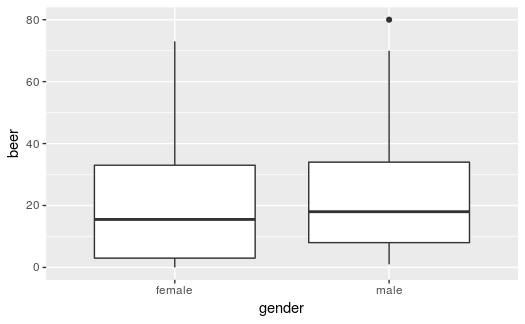

```r
ggplot(data=stereotypes, aes(x=gender, y=beer)) +geom_boxplot()
```

The last command is the control/comparison group that has all the populations.

2.Using theggplot2 documentation, explore three different geoms, using either the full data set or a subset of the data. Tell me something interesting about the data.

```r
ggplot(stereotypes, aes(beer, tacos, color = population, shape = gender)) + geom_point()
males<- subset(stereotypes, gender == "male")
females<- subset(stereotypes, gender == "female")
ggplot(data=males, aes( x=population, y=computer, colour=population)) +geom_boxplot()
ggplot(data=females, aes( x=population, y=computer, colour=population)) +geom_boxplot()

ggplot(data=stereotypes, aes( x=gender, y=computer, colour=population)) +geom_boxplot()
```

[output not shown]

All males, except male nerds, on average spend more time than their female population counterparts on the computer.

3.From your exploration of the stereotypes data make three hypotheses about the data.

Nerds stay indoors more often on the computer and so they have more immediate access to the shower.

Tacos and Beer are meant to be together (they’re offered at the same places).

Computers are usually marketed as to males, so they usually spend more time on the computers.

**Visualization with the ggplot() function**

With the p base layer, make a unique plot by adding additional layers.

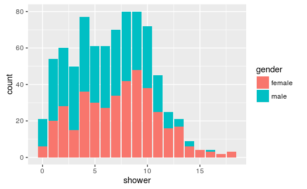

```r
p <- ggplot(stereotypes, aes(shower, fill = gender))
p + geom_bar()
```

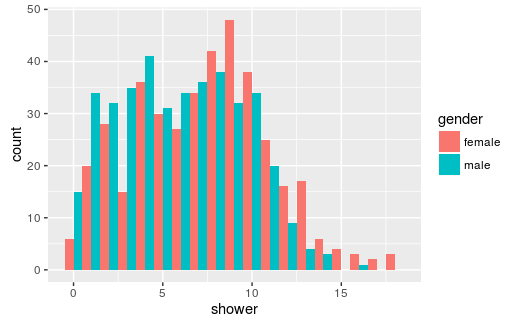

```r
p + geom_histogram(binwidth = 1, position = "dodge")
```

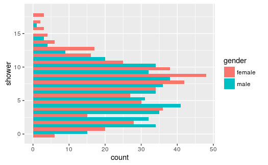

```r
p + geom_histogram(binwidth = 1, position = "dodge") + coord_flip()
```

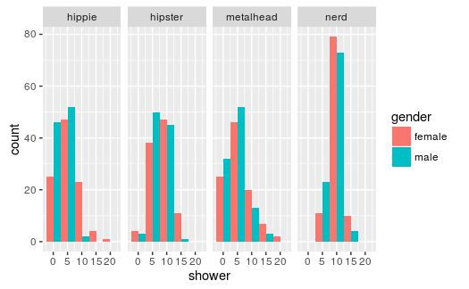

```r
p + geom_histogram(binwidth = 5, position = "dodge") + facet_grid(~population)
```

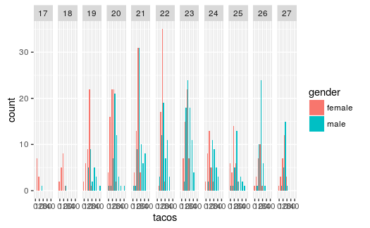

```r
p <- ggplot(stereotypes, aes(tacos, fill = gender))
p+ geom_histogram(binwidth=5,position = "dodge") +facet_grid(~age)
```

Make new base layer. Explore what the difference is between color = and fill =. Use your own words to discern the difference.

*fill* fills the whole bar with color *colour* just assigns color to the variables but it doesn’t necessarily completely fill it in.

**Visualization with the ggplot() function with more color adjustments**

Read about and use the following modifiers correctly with the any portion of the sterotypes dataset you want.

1.Modify color with scale_color_hue()

```r
ggplot(stereotypes, aes(age, tacos, color = population)) +
    geom_point()+ scale_color_hue()
```

[output not shown]

2.Make a tricked out box plot using the stereotypes data. Use at least 3 of the aesthetic options available for geom_boxplot. Use ggplot2 boxplot documentation for guidance.

(used facid grid, outlier coloring, scale_fill_hue, and adding the notch)

```r
ggplot(stereotypes, aes(age, tacos, color = population)) +
    geom_boxplot(outlier.color = "red",notch=TRUE)+scale_fill_hue()+facet_grid(~population)
```

[output not shown]

## Exercise 12

*Use ggplot to explore the relationship between score (“Score”) and alignment length(“len”). Provide a plot that illustrates the relationship and describe the relationship in words.*

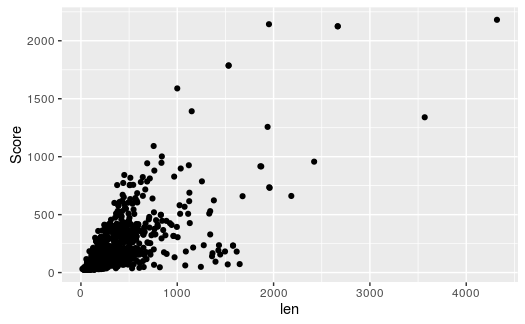

```r
fly.worm.small<-fly.worm[sample(nrow(fly.worm), 1000),]
ggplot(fly.worm.small, aes(len,Score))+geom_point()
```

Roughly, it looks like alignment length and score are positively correlated, but the variance seems fairly large. The variance is especially strong with lengths under 2000.

## Excercise 13

*While you might expect that BLAST results with long alignments would have high scores, this is not always the case. Form a hypothesis as to what might influence the relationship between alignment length and score. Use ggplot to make a new plot to explore this hypothesis. Does the plot support your hypothesis or not? State your hypothesis, provide the code for your plot, and state your conclusion.*

```r
ggplot(fly.worm.small, aes(len, Score, color=gaps)) + geom_point()
```

[output not shown]

Lines that begin with a pound sign # are comment lines and are ignored by R.